# 03_stats_assessment CG and CH seq preferences (no coverage filtering)

Izaskun Mallona

Requires `02_motif_extract_run_nov_2019_no_coverage_filtering_postproc.Rmd` to be run first.

Motifs are classified as methylated or unmethylated and counted, without aggregating average methylation values per sample to avoid batch/genotype effects.

Started 27 Feb 2020

# Config

```r
opts_chunk$set(fig.width = 8,
               fig.height = 8,
               cache = TRUE,
               include = TRUE,
               cache.lazy = FALSE,
               warning = TRUE,
               message = TRUE)
```

# Data retrieval

The object was generated by `02_motif_extract_run_nov_2019_no_coverage_filtering_postproc.Rmd`

It is tracked at `./data/counts_nested_list.RData` as well

```r
con <- url('http://imlstaupo.uzh.ch/imallona/baubec/cg_context/counts_nested_list.RData')
load(con)
close(con)
```

## Permutation analysis on `tko+d3a2_merged`

To check whether the proportion of methylated sites versus the unmethylated sites (or versus the coverage), we need to run a test that maintains the average DNA methylation of that sample.

We do this in two ways.

- (permute motifs strategy) First, permuting the motifs a certain number of times.
- (permute 2d strategy) Or permuting both the methylated and the unmethylated counts a certain number of times.

The first approach is the soundest to detect motifs that deviate from the observations.

```r
## stopifnot(all(d$cg$`tko+d3a2_merged`$meth$motif == d$cg$`tko+d3a2_merged`$unmeth$motif))

## a <- data.frame(motif = d$cg$`tko+d3a2_merged`$meth$motif,
##                 meth = d$cg$`tko+d3a2_merged`$meth$count,
##                 unmeth = d$cg$`tko+d3a2_merged`$unmeth$count)

## keeping_meth_and_unmeth_blocks
permute_motifs <- function(fd, n = 1000) {

    res <- list()
    for (i in 1: n) {
        idx <- sample(x = rownames(fd), size = nrow(fd), replace = FALSE)
        res[[i]] <- data.frame(motif = fd$motif,
                               meth = fd[idx, 'meth'],
                               unmeth = fd[idx, 'unmeth'])

        rownames(res[[i]]) <- res[[i]]$motif

        res[[i]]$score <- res[[i]]$meth / (res[[i]]$meth  + res[[i]]$unmeth)

    }
    return(res)
}


permute_2d <- function(fd, n = 1000) {
    res <- list()
    for (i in 1: n) {
        idx <- sample(x = rownames(fd), size = nrow(fd), replace = FALSE)
        idx2 <- sample(x = rownames(fd), size = nrow(fd), replace = FALSE)
        res[[i]] <- data.frame(motif = fd$motif,
                               meth = fd[idx, 'meth'],
                               unmeth = fd[idx2, 'unmeth'])

        rownames(res[[i]]) <- res[[i]]$motif

        res[[i]]$score <- res[[i]]$meth / (res[[i]]$meth  + res[[i]]$unmeth)
    }

    return(res)
}

## note that permutation p-values should never be 0;
## we add `1` to the one-tailed test to include the observation on top to the
##   number of permutations
run_permutation_test <- function(fd, permutation_type, n = 1000, adjust.FDR = TRUE) {
    if (permutation_type == 'motifs') {
        res <- permute_motifs(fd, n)
    }
    else if (permutation_type == '2d') {
        res <- permute_2d(fd, n)
    }
    else {
        stop('wrong permutation type')
    }

    fd$pval <- NA
    fd$qval <- NA

    for (motif in rownames(fd)){
        fd[motif, 'pval'] <- (sum(
            sapply(res,
                   function(x) fd[motif,]$score <= x[motif,]$score)) + 1) / (n + 1)
        if(fd[motif, 'pval'] > 1) stop()

    }

    if (adjust.FDR) {
        fd$qval <- p.adjust(fd$pval, method = 'BH')
    }

    return(fd)
}
```

# Permutation analysis on `tko+d3a2_merged`

Permuting motifs in DNMT D3A2

```r
stopifnot(all(d$cg$`tko+d3a2_merged`$meth$motif == d$cg$`tko+d3a2_merged`$unmeth$motif))

a <- data.frame(motif = d$cg$`tko+d3a2_merged`$meth$motif,
                meth = d$cg$`tko+d3a2_merged`$meth$count,
                unmeth = d$cg$`tko+d3a2_merged`$unmeth$count)

rownames(a) <- a$motif
a$score <- a$meth / (a$meth + a$unmeth)
head(a$score)
```

```
## [1] 0.23447712 0.20561941 0.09213401 0.12208259 0.21146953 0.15753425
```

```r
a_motif_perm <- run_permutation_test(fd = a,
                                     n = 200,
                                     permutation_type = 'motifs',
                                     adjust.FDR = TRUE)


summary(a_motif_perm)
```

```
##       motif           meth            unmeth           score
##  AAACGAAA:   1   Min.   :   4.0   Min.   :  24.0   Min.   :0.02212
##  AAACGAAC:   1   1st Qu.: 104.0   1st Qu.: 245.0   1st Qu.:0.20432
##  AAACGAAG:   1   Median : 232.0   Median : 450.0   Median :0.32298
##  AAACGAAT:   1   Mean   : 284.8   Mean   : 601.6   Mean   :0.33514
##  AAACGACA:   1   3rd Qu.: 391.0   3rd Qu.: 769.2   3rd Qu.:0.45608
##  AAACGACC:   1   Max.   :3939.0   Max.   :8815.0   Max.   :0.76478
##  (Other) :4090
##       pval               qval
##  Min.   :0.004975   Min.   :0.9263
##  1st Qu.:0.253731   1st Qu.:0.9909
##  Median :0.507463   Median :0.9939
##  Mean   :0.502587   Mean   :0.9901
##  3rd Qu.:0.751244   3rd Qu.:0.9962
##  Max.   :1.000000   Max.   :1.0000
##
```

```r
table(a_motif_perm$pval < 0.05)
```

```
##
## FALSE  TRUE
##  3894   202
```

```r
table(a_motif_perm$qval < 0.05)
```

```
##
## FALSE
##  4096
```

Permuting meth and unmeth counts in DNMT D3A2

```
a_all_perm <- run_permutation_test(fd = a,
                                   n = 200,
                                   permutation_type = '2d',
                                   adjust.FDR = TRUE)

summary(a_all_perm)
table(a_all_perm$pval < 0.05)
table(a_all_perm$qval < 0.05)
```

Comparing both permutation strategies.

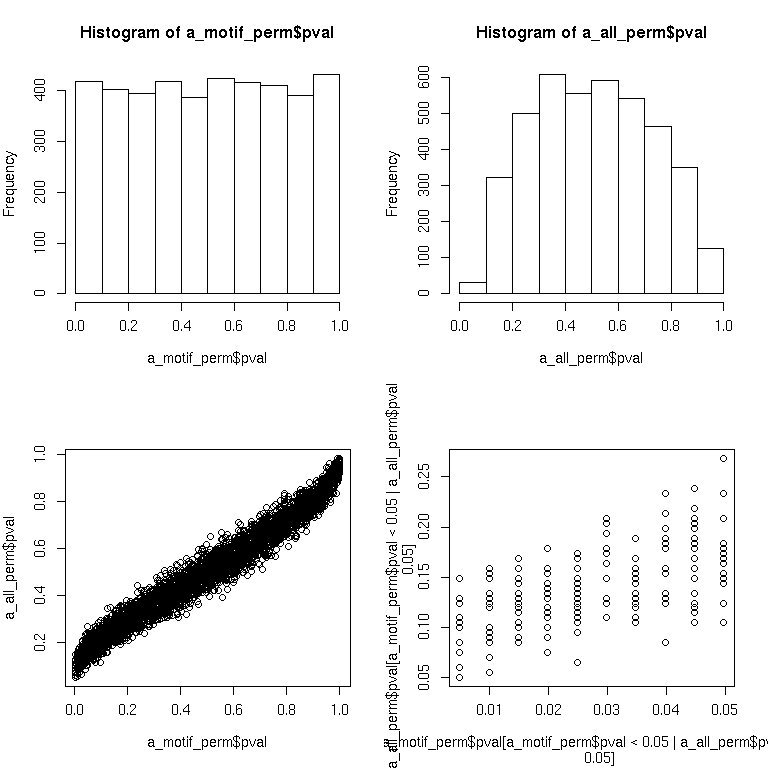

```r
par(mfrow = c(2,2))
hist(a_motif_perm$pval)
hist(a_all_perm$pval)

plot(a_motif_perm$pval, a_all_perm$pval)

plot(a_motif_perm$pval[a_motif_perm$pval < 0.05 | a_all_perm$pval < 0.05 ],
     a_all_perm$pval[a_motif_perm$pval < 0.05 | a_all_perm$pval < 0.05 ])
```

Plots with marginals

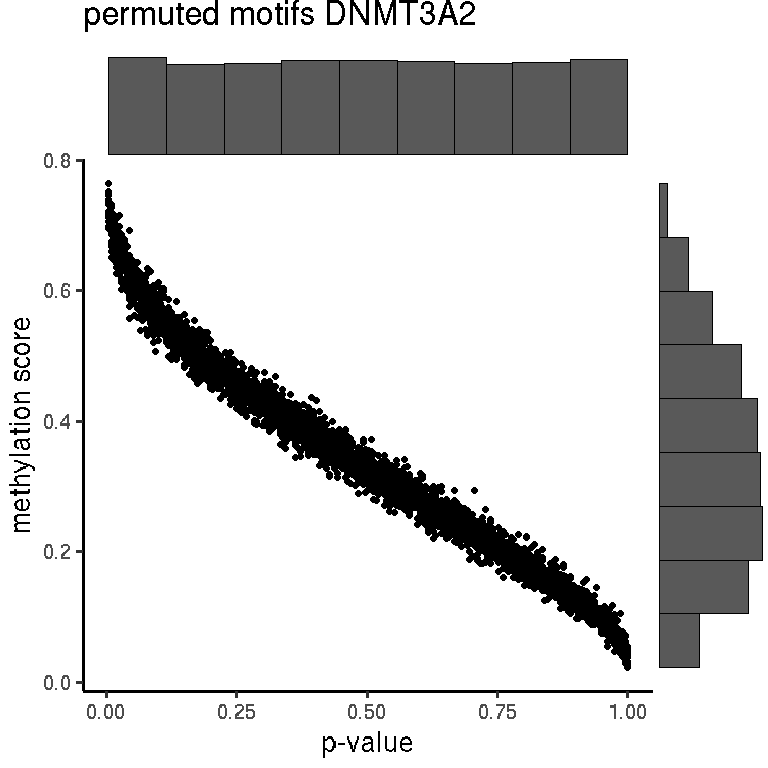

```r
p <- ggplot(a_motif_perm, aes(y = score, x = pval)) +
    geom_point() +
    theme_classic(base_size = 20) +
    ylab('methylation score') +
    xlab('p-value') +
    ggtitle('permuted motifs DNMT3A2')

ggMarginal(p, type = "histogram", bins = 10, colour = 'black')#, groupColour = TRUE)
```

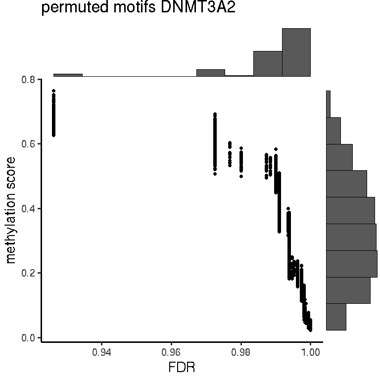

```r
p <- ggplot(a_motif_perm, aes(x=qval, y=score)) +
    geom_point() +
    theme_classic(base_size = 20) +
    ylab('methylation score') +
    xlab ('FDR') +
    ggtitle('permuted motifs DNMT3A2')

ggMarginal(p, type = "histogram", bins = 10, colour = 'black')
```

[figure not shown]

```r
p <- ggplot(data = data.frame(pval_a = a_motif_perm$pval,
                              pval_b = b_motif_perm$pval),
                aes(x=pval_a, y = pval_b)) +
    geom_point() +
    theme_classic(base_size = 20) +
    ylab('pval d3a2') +
    xlab ('pval d3b1') + ggtitle('permuted motifs')


ggMarginal(p, type = "histogram", bins = 10, colour = 'black')
```

## Permutation analysis on `tko+d3b1_merged`

Data reshaping for tko+d3b1

```r
b <- data.frame(motif = d$cg$`tko+d3b1_merged`$meth$motif,
                meth = d$cg$`tko+d3b1_merged`$meth$count,
                unmeth = d$cg$`tko+d3b1_merged`$unmeth$count)

rownames(b) <- b$motif
b$score <- b$meth / (b$meth + b$unmeth)
head(b$score)
```

```
## [1] 0.2138050 0.2178974 0.1263690 0.1726921 0.1720183 0.1695652
```

Permuting motifs in tko+d3b1

```r
b_motif_perm <- run_permutation_test(fd = b,
                                     n = 200,
                                     permutation_type = 'motifs',
                                     adjust.FDR = TRUE)


summary(b_motif_perm)
```

```
##       motif           meth            unmeth          score
##  AAACGAAA:   1   Min.   :   0.0   Min.   :   85   Min.   :0.00000
##  AAACGAAC:   1   1st Qu.:  33.0   1st Qu.:  703   1st Qu.:0.03496
##  AAACGAAG:   1   Median : 113.0   Median : 1202   Median :0.08761
##  AAACGAAT:   1   Mean   : 203.0   Mean   : 1442   Mean   :0.12120
##  AAACGACA:   1   3rd Qu.: 277.2   3rd Qu.: 1846   3rd Qu.:0.18668
##  AAACGACC:   1   Max.   :4447.0   Max.   :14735   Max.   :0.58890
##  (Other) :4090
##       pval               qval
##  Min.   :0.004975   Min.   :0.9762
##  1st Qu.:0.253731   1st Qu.:0.9860
##  Median :0.502488   Median :0.9922
##  Mean   :0.502433   Mean   :0.9909
##  3rd Qu.:0.751244   3rd Qu.:0.9972
##  Max.   :1.000000   Max.   :1.0000
##
```

```r
table(b_motif_perm$pval < 0.05)
```

```
##
## FALSE  TRUE
##  3897   199
```

```r
table(b_motif_perm$qval < 0.05)
```

```
##
## FALSE
##  4096
```

Permuting meth and unmeth counts for tko+d3b1

```r
b_all_perm <- run_permutation_test(fd = b,
                                   n = 200,
                                   permutation_type = '2d',
                                   adjust.FDR = TRUE)

summary(b_all_perm)
```

```
##       motif           meth            unmeth          score
##  AAACGAAA:   1   Min.   :   0.0   Min.   :   85   Min.   :0.00000
##  AAACGAAC:   1   1st Qu.:  33.0   1st Qu.:  703   1st Qu.:0.03496
##  AAACGAAG:   1   Median : 113.0   Median : 1202   Median :0.08761
##  AAACGAAT:   1   Mean   : 203.0   Mean   : 1442   Mean   :0.12120
##  AAACGACA:   1   3rd Qu.: 277.2   3rd Qu.: 1846   3rd Qu.:0.18668
##  AAACGACC:   1   Max.   :4447.0   Max.   :14735   Max.   :0.58890
##  (Other) :4090
##       pval              qval
##  Min.   :0.03483   Min.   :0.9324
##  1st Qu.:0.29353   1st Qu.:0.9324
##  Median :0.50249   Median :0.9324
##  Mean   :0.50526   Mean   :0.9340
##  3rd Qu.:0.71144   3rd Qu.:0.9324
##  Max.   :1.00000   Max.   :1.0000
##
```

```r
table(b_all_perm$pval < 0.05)
```

```
##
## FALSE  TRUE
##  4087     9
```

```r
table(b_all_perm$qval < 0.05)
```

```
##
## FALSE
##  4096
```

Comparing both permutation strategies.

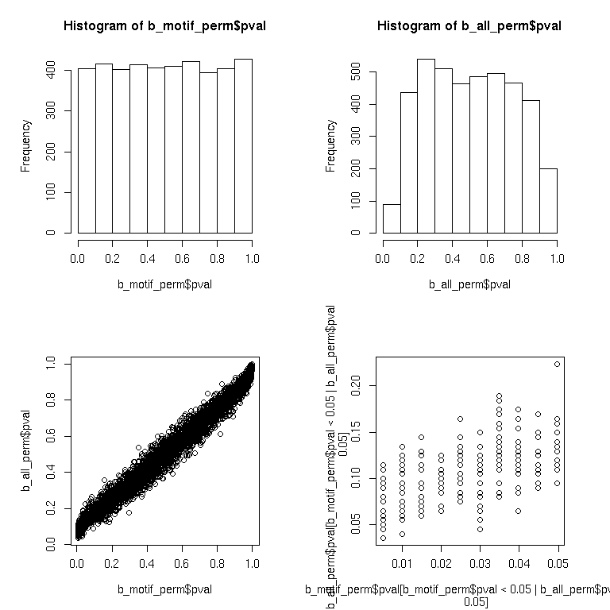

```r
par(mfrow = c(2,2), pty = 's')
hist(b_motif_perm$pval)
hist(b_all_perm$pval)

plot(b_motif_perm$pval, b_all_perm$pval)

plot(b_motif_perm$pval[b_motif_perm$pval < 0.05 | b_all_perm$pval < 0.05 ],
     b_all_perm$pval[b_motif_perm$pval < 0.05 | b_all_perm$pval < 0.05 ])
```

## Comparing DNMT3A and DNMT3B meth preferences according to the permutation outputs

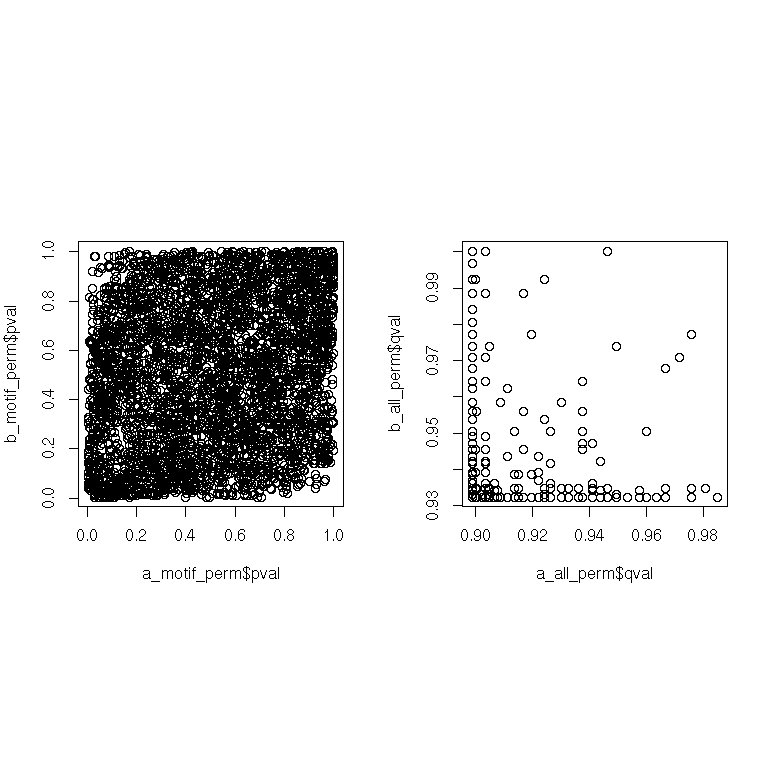

```r
par(mfrow = c(1,2), pty = 's')

plot(a_motif_perm$pval, b_motif_perm$pval)
plot(a_all_perm$qval, b_all_perm$qval)
```

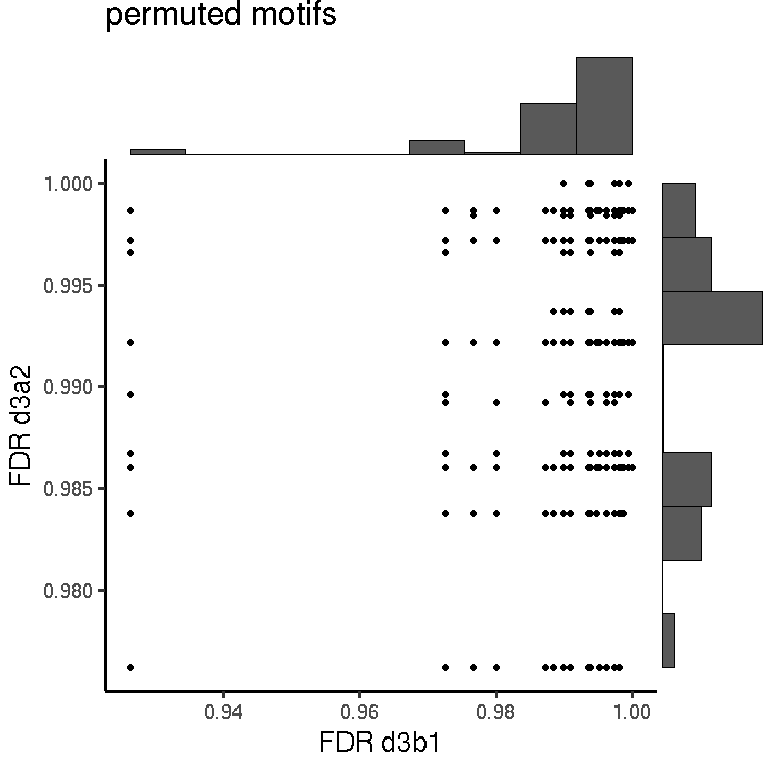

```r
p <- ggplot(data = data.frame(qval_a = a_motif_perm$qval,
                              qval_b = b_motif_perm$qval),
                aes(x=qval_a, y = qval_b)) +
    geom_point() +
    theme_classic(base_size = 20) +
    ylab('FDR d3a2') +
    xlab ('FDR d3b1') +
    ggtitle('permuted motifs')

ggMarginal(p, type = "histogram", bins = 10, colour = 'black')#, groupColour = TRUE)
```

# By proportion tests

## CG

We’ll check the methylation success per motif according to the enzyme added back. We’ll directly compare DNMT3A and DNMT3B.

Because of the upper plot (section `Comparing DNMT3A and DNMT3B meth preferences according to the permutation outputs`) it’s expected that success rate (proportion of methylated vs unmethylated) for most of the motifs will be different. The H0 (null of proportions being the same in DNMT3A and DNMT3B) will most probably be rejected for most cases.

```r
stopifnot(all(d$cg$`tko+da3a2_merged`$meth$motif == d$cg$`tko+d3b1_merged`$unmeth$motif))
```

Assuming independences and H0: methylation proportion in DNMT3A and DNMT3b are the same, iterating all motifs as follows?

```r
prop_test_to_iterate <- function(a, b, motif) {
    curr <- as.data.frame(matrix(data = NA, nrow = 2, ncol = 2))

    curr[1,] <- as.numeric(a[motif, c('meth', 'unmeth')])
    curr[2,] <- as.numeric(b[motif, c('meth', 'unmeth')])

    colnames(curr) <- c('meth', 'unmeth')
    rownames(curr) <- sprintf('%s_%s', motif, c('a', 'b'))

    return(list(table = curr,
                test = prop.test(x = curr$meth, n = curr$meth + curr$unmeth, correct = TRUE)))
}

## reto <-prop_test_to_iterate(a = a, b = b, motif = 'AAACGAAA')
## prop_test_to_iterate(a = a, b = b, motif = 'AAACGAAT')
## prop_test_to_iterate(a = a, b = b, motif = 'AAACGCGC')
```

```r
ptests_list <- list()

for (motif in a$motif) {
    ptests_list[[motif]] <- prop_test_to_iterate(a = a, b = b, motif = motif)
}
```

[output not shown]

```r
ptests <- data.frame(motif = names(sapply(ptests_list, function(x) return(x$test$p.value))),
                  pval = as.numeric(sapply(ptests_list, function(x) return(x$test$p.value))))

rownames(ptests) <- ptests$motif

ptests$qval <- p.adjust(ptests$pval, method = 'BH')

table(ptests$qval < 0.05)
```

```
##
## FALSE  TRUE
##   350  3746
```

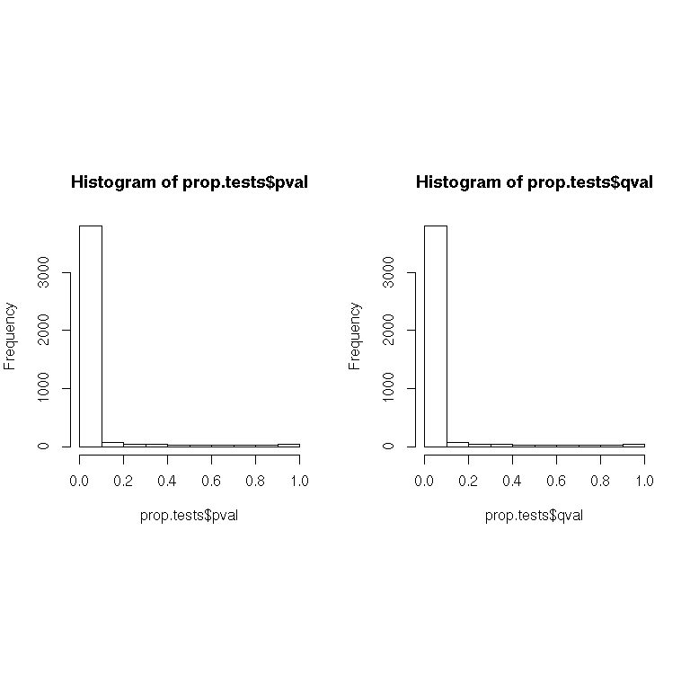

```r
par(mfrow = c(1,2), pty = 's')
hist(prop.tests$pval)
hist(prop.tests$qval)
```

## Plot z-scores and plot the delta A-B as well to grasp the extent of the change.

```r
## modified from gCMAP::zScores
zscore_from_pval <- function (pval, direction = NULL, tails = 1, limit = .Machine$double.xmin){
    if (!is.null(limit)) {
        pval[which(pval < limit)] <- limit
    }
    if (tails == 2) {
        z <- qnorm(pval/2, lower.tail = FALSE)
    }
    else if (tails == 1) {
        z <- qnorm(pval, lower.tail = FALSE)
    }
    else {
        stop("Parameter 'tails' must be set to either 1 or 2.")
    }

    ## direction of change
    if (!is.null(direction)) {
        z <- z * sign(direction)
    }
    return(z)
}
```

```r
prop.tests$delta <- a[rownames(prop.tests), 'score'] - b[rownames(prop.tests), 'score']
prop.tests$ascore <-  a[rownames(prop.tests), 'score']
prop.tests$bscore <- b[rownames(prop.tests), 'score']
prop.tests$zscore <- zscore_from_pval(prop.tests$pval, direction = prop.tests$delta, tails = 2)

summary(prop.tests)
```

[output not shown]

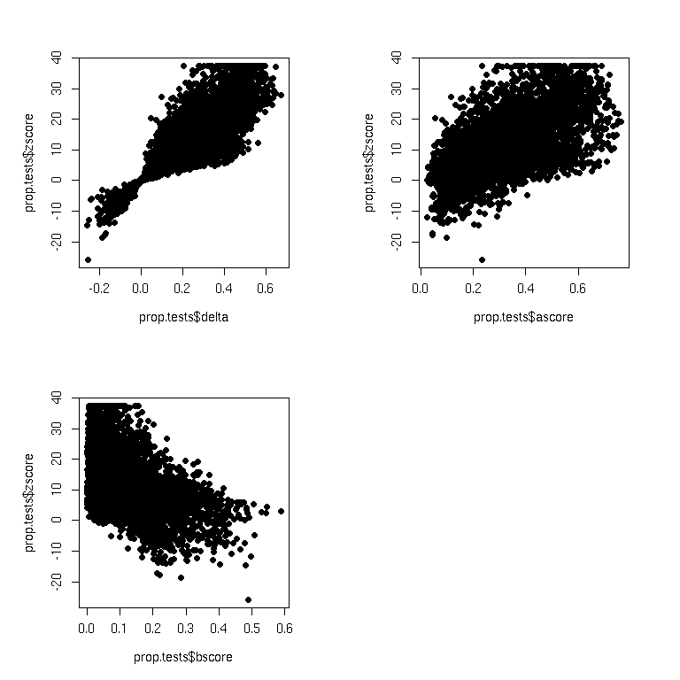

```r
## plot(prop.tests)
par(mfrow = c(2,2), pty = 's')

plot(prop.tests$delta, prop.tests$zscore, pch = 19)
plot(prop.tests$ascore, prop.tests$zscore, pch = 19)
plot(prop.tests$bscore, prop.tests$zscore, pch = 19)
```

Sort the motifs by their zscore and then the delta of the scores, and plot the trends

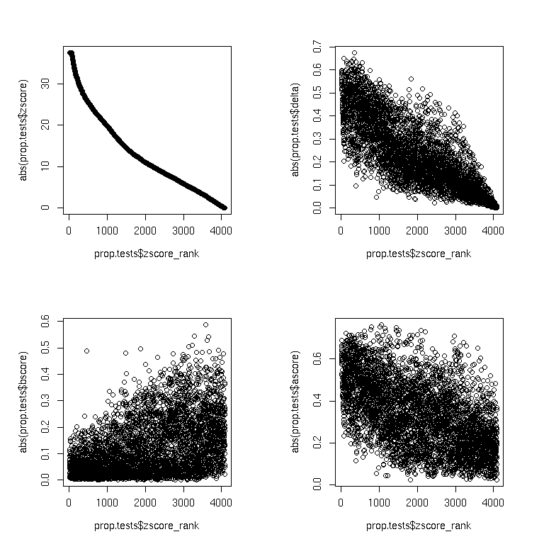

```r
prop.tests <- prop.tests[order(abs(prop.tests$zscore), prop.tests$delta,
                               decreasing = TRUE),]
prop.tests$zscore_rank <- 1:nrow(prop.tests)

par(mfrow = c(2,2), pty = 's')
plot(y = abs(prop.tests$zscore), x = prop.tests$zscore_rank)
plot(y = abs(prop.tests$delta), x = prop.tests$zscore_rank)
plot(y = abs(prop.tests$bscore), x = prop.tests$zscore_rank)
plot(y = abs(prop.tests$ascore), x = prop.tests$zscore_rank)
```

# Timestamp

```r
date()
```

```
## [1] "Mon Mar  2 15:48:39 2020"
```